# Clase 18b: Análisis no supervisado y K-means con adult.csv

Laura Katherine Martinez Castiblanco

## 1. Contexto del problema

Se dispone del dataset `adult.csv` (Census Income), que contiene información demográfica y laboral de 32 561 adultos. El objetivo del taller 18b es descubrir grupos naturales entre los individuos usando K-means, sin usar la variable respuesta (`income`). Luego se compararán los clusters encontrados con la etiqueta real para evaluar qué tanto la estructura no supervisada coincide con el nivel de ingresos.

### Variables seleccionadas para agrupar

Se usan únicamente variables numéricas continuas que describen perfil socioeconómico y laboral:

| Variable | Descripción |
| --- | --- |
| `age` | Edad en años |
| `education.num` | Años de educación (codificación numérica) |
| `hours.per.week` | Horas trabajadas por semana |
| `capital.gain` | Ganancia de capital (inversiones, ventas de activos) |

La variable respuesta `income` (≤50K / >50K) se aparta antes de agrupar.

## 2. Carga de datos y preparación

```r
# Lectura del archivo (ajusta la ruta si tu archivo está en otra carpeta)
adult <- read.csv("../adult.csv", stringsAsFactors = FALSE)

cat("Dimensiones originales:", nrow(adult), "filas x", ncol(adult), "columnas\n")
```

```
## Dimensiones originales: 32561 filas x 15 columnas
```

```r
mostrar_tabla(adult, caption = "Primeros registros de adult.csv")
```

Primeros registros de adult.csv

| age | workclass | fnlwgt | education | education.num | marital.status | occupation | relationship | race | sex | capital.gain | capital.loss | hours.per.week | native.country | income |
| --- | --- | --- | --- | --- | --- | --- | --- | --- | --- | --- | --- | --- | --- | --- |
| 90 | ? | 77053 | HS-grad | 9 | Widowed | ? | Not-in-family | White | Female | 0 | 4356 | 40 | United-States | <=50K |
| 82 | Private | 132870 | HS-grad | 9 | Widowed | Exec-managerial | Not-in-family | White | Female | 0 | 4356 | 18 | United-States | <=50K |
| 66 | ? | 186061 | Some-college | 10 | Widowed | ? | Unmarried | Black | Female | 0 | 4356 | 40 | United-States | <=50K |
| 54 | Private | 140359 | 7th-8th | 4 | Divorced | Machine-op-inspct | Unmarried | White | Female | 0 | 3900 | 40 | United-States | <=50K |
| 41 | Private | 264663 | Some-college | 10 | Separated | Prof-specialty | Own-child | White | Female | 0 | 3900 | 40 | United-States | <=50K |
| 34 | Private | 216864 | HS-grad | 9 | Divorced | Other-service | Unmarried | White | Female | 0 | 3770 | 45 | United-States | <=50K |
| 38 | Private | 150601 | 10th | 6 | Separated | Adm-clerical | Unmarried | White | Male | 0 | 3770 | 40 | United-States | <=50K |
| 74 | State-gov | 88638 | Doctorate | 16 | Never-married | Prof-specialty | Other-relative | White | Female | 0 | 3683 | 20 | United-States | >50K |
| 68 | Federal-gov | 422013 | HS-grad | 9 | Divorced | Prof-specialty | Not-in-family | White | Female | 0 | 3683 | 40 | United-States | <=50K |
| 41 | Private | 70037 | Some-college | 10 | Never-married | Craft-repair | Unmarried | White | Male | 0 | 3004 | 60 | ? | >50K |

Selección de variables y separación de la respuesta

```r
# Variables para agrupar (según instrucciones de la Clase 18b)
vars_cluster <- c("age", "education.num", "hours.per.week", "capital.gain")

# Verificación de que las columnas existen
stopifnot(all(vars_cluster %in% names(adult)))

# Matriz X (solo predictoras numéricas) — la respuesta se aparta
X <- adult %>% select(all_of(vars_cluster))
y <- adult$income   # se guarda para el cruce posterior, NO se usa en K-means

glimpse(X)
```

```
## Rows: 32,561
## Columns: 4
## $ age            <int> 90, 82, 66, 54, 41, 34, 38, 74, 68, 41, 45, 38, 52, 32,…
## $ education.num  <int> 9, 9, 10, 4, 10, 9, 6, 16, 9, 10, 16, 15, 13, 14, 16, 1…
## $ hours.per.week <int> 40, 18, 40, 40, 40, 45, 40, 20, 40, 60, 35, 45, 20, 55,…
## $ capital.gain   <int> 0, 0, 0, 0, 0, 0, 0, 0, 0, 0, 0, 0, 0, 0, 0, 0, 0, 0, 0…
```

K-means no acepta `NA`. Revisamos y, si existen, los eliminamos de `X` y de `y` en paralelo para mantener la alineación.

```r
na_por_col <- colSums(is.na(X))
cat("NA por columna en X:\n")
```

```
## NA por columna en X:
```

```r
print(na_por_col)
```

```
##            age  education.num hours.per.week   capital.gain
##              0              0              0              0
```

```r
# Eliminación lista completa (solo si hay NA)
if (any(na_por_col > 0)) {
  idx_na   <- !complete.cases(X) | is.na(y)
  X        <- X[!idx_na, ]
  y        <- y[!idx_na]
  cat("Filas eliminadas por NA:", sum(idx_na), "\n")
}

cat("Dimensión final de X:", nrow(X), "x", ncol(X), "\n")
```

```
## Dimensión final de X: 32561 x 4
```

## 3. Escalado de variables

K-means minimiza la inercia (suma de distancias euclidianas al cuadrado). La distancia euclidiana es sensible a la escala: una variable medida en miles dominará el cálculo frente a una medida en unidades.

los rangos originales:

```r
X %>%
  summarise(across(everything(), list(
    min  = ~min(.),
    max  = ~max(.),
    mean = ~mean(.),
    sd   = ~sd(.)
  ))) %>%
  pivot_longer(everything(),
               names_sep   = "_",
               names_to    = c("variable", "estadistico")) %>%
  pivot_wider(names_from = estadistico, values_from = value) %>%
  kable(caption = "Estadísticos descriptivos antes del escalado")
```

Estadísticos descriptivos antes del escalado

| variable | min | max | mean | sd |
| --- | --- | --- | --- | --- |
| age | 17 | 90 | 38.58165 | 13.64043 |
| education.num | 1 | 16 | 10.08068 | 2.57272 |
| hours.per.week | 1 | 99 | 40.43746 | 12.34743 |
| capital.gain | 0 | 99999 | 1077.64884 | 7385.29208 |

Se observa que `capital.gain` tiene valores hasta ~100 000 mientras que `age` va de 17 a 90. Sin escalar, la distancia estaría dominada casi exclusivamente por `capital.gain`, y las demás variables serían ignoradas por el algoritmo, produciendo clusters artificiales basados solo en ganancias de capital.

### Estandarización (z-score):

```r
X_esc <- as.data.frame(scale(X))

X_esc %>%
  summarise(across(everything(), list(
    mean = ~round(mean(.), 6),
    sd   = ~round(sd(.),   6)
  ))) %>%
  kable(caption = "Estadísticos después del escalado (media≈0, sd≈1)")
```

Estadísticos después del escalado (media≈0, sd≈1)

| age_mean | age_sd | education.num_mean | education.num_sd | hours.per.week_mean | hours.per.week_sd | capital.gain_mean | capital.gain_sd |
| --- | --- | --- | --- | --- | --- | --- | --- |
| 0 | 1 | 0 | 1 | 0 | 1 | 0 | 1 |

Todas las variables quedan en escala comparable: media ≈ 0 y desviación estándar ≈ 1.

## 4. Elección del número de clusters (K)

`adult.csv` tiene 32 561 filas; calcular la silueta sobre el dataset completo es costoso. Siguiendo la indicación de la Clase 18b, trabajamos sobre una muestra de 5 000 filas para la selección de K.

```r
set.seed(2026)
n_muestra <- 5000
idx_muestra <- sample(nrow(X_esc), n_muestra)
X_muestra   <- X_esc[idx_muestra, ]
y_muestra   <- y[idx_muestra]

cat("Tamaño de la muestra:", nrow(X_muestra), "\n")
```

```
## Tamaño de la muestra: 5000
```

### 4.2 Inercia (método del codo) y silueta para K = 2, …, 8

```r
K_vals    <- 2:8
inercias  <- numeric(length(K_vals))
siluetas  <- numeric(length(K_vals))

set.seed(2026)
for (i in seq_along(K_vals)) {
  k            <- K_vals[i]
  km           <- kmeans(X_muestra, centers = k, nstart = 25, iter.max = 100)
  inercias[i]  <- km$tot.withinss
  sil          <- silhouette(km$cluster, dist(X_muestra))
  siluetas[i]  <- mean(sil[, "sil_width"])
}

resumen_k <- tibble(
  K        = K_vals,
  Inercia  = round(inercias, 2),
  Silueta  = round(siluetas, 4)
)

kable(resumen_k, caption = "Inercia y silueta promedio para K = 2 a 8")
```

Inercia y silueta promedio para K = 2 a 8

| K | Inercia | Silueta |
| --- | --- | --- |
| 2 | 15590.11 | 0.8366 |
| 3 | 11993.75 | 0.2427 |
| 4 | 9314.16 | 0.2892 |
| 5 | 7932.56 | 0.3086 |
| 6 | 6776.10 | 0.3175 |
| 7 | 5958.99 | 0.3269 |
| 8 | 5270.28 | 0.3271 |

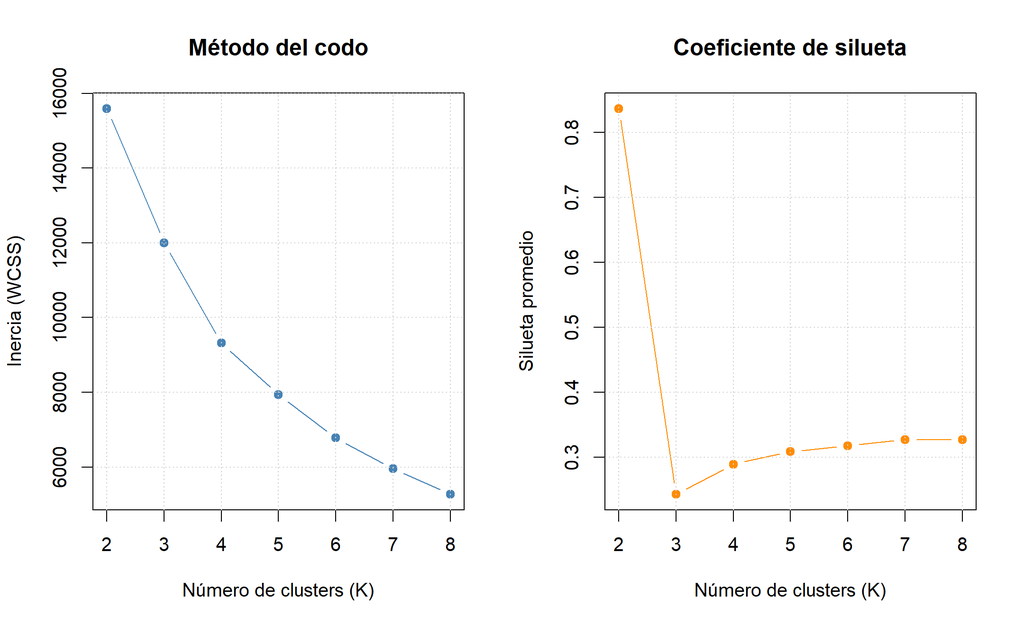

Método del codo (izq.) y silueta promedio (der.)

```r
par(mfrow = c(1, 2))

# Codo
plot(K_vals, inercias, type = "b", pch = 19, col = "steelblue",
     xlab = "Número de clusters (K)", ylab = "Inercia (WCSS)",
     main = "Método del codo")
grid()

# Silueta
plot(K_vals, siluetas, type = "b", pch = 19, col = "darkorange",
     xlab = "Número de clusters (K)", ylab = "Silueta promedio",
     main = "Coeficiente de silueta")
grid()
```

Para identificar el codo con mayor objetividad, se calculan las diferencias entre inercias consecutivas:

```r
deltas_inercia <- diff(inercias)
nombres_deltas <- paste0("K=", K_vals[-length(K_vals)], " → K=", K_vals[-1])

tibble(
  Transicion         = nombres_deltas,
  Caida_Inercia      = round(abs(deltas_inercia), 2),
  Caida_Relativa_pct = round(abs(deltas_inercia) / inercias[-length(inercias)] * 100, 2)
) %>%
  kable(caption = "Caídas absolutas y relativas de la inercia entre K consecutivos")
```

Caídas absolutas y relativas de la inercia entre K consecutivos

| Transicion | Caida_Inercia | Caida_Relativa_pct |
| --- | --- | --- |
| K=2 → K=3 | 3596.36 | 23.07 |
| K=3 → K=4 | 2679.59 | 22.34 |
| K=4 → K=5 | 1381.59 | 14.83 |
| K=5 → K=6 | 1156.46 | 14.58 |
| K=6 → K=7 | 817.12 | 12.06 |
| K=7 → K=8 | 688.70 | 11.56 |

Se selecciona K = 4 se sustenta en tres criterios convergentes que, evaluados en conjunto, señalan un punto de equilibrio entre compactación, separación e interpretabilidad:

#### Criterio 1 — Punto de inflexión en el método del codo (inercia)

Las mayores reducciones de varianza intra-cluster (WCSS) ocurren al pasar de:

- K = 2 → K = 3: caída de 3 596.36 unidades de inercia.
- K = 3 → K = 4: caída de 2 679.59 unidades.

A partir de K = 4 la curva se aplana: el salto a K = 5 cae a la mitad (1 381.60), lo que indica rendimientos decrecientes claros. Agregar más clusters a partir de 4 aporta cada vez menos compactación por grupo añadido, señal clásica de codo.

#### Criterio 2 — Recuperación de la silueta tras aislar los outliers

La silueta presenta un comportamiento no monótono que solo se explica al analizar la estructura interna:

[output not shown]

#### Criterio 3 — Interpretabilidad en la fase de evaluación KDD

Con K = 4 se obtiene una partición con sentido de negocio:

- 3 perfiles socioeconómicos bien diferenciados por edad, nivel educativo y horas semanales trabajadas.
- 1 segmento de ganancias de capital extraordinarias, que agrupa a los ~159 individuos con `capital.gain` muy por encima del resto.

Esta estructura evita fragmentar innecesariamente la muestra (como ocurriría con K ≥ 5) y a la vez no colapsa perfiles distintos (como ocurriría con K ≤ 3). Es el número de grupos que mejor balancea la fidelidad a la estructura de los datos con la utilidad para la toma de decisiones.

> Decisión final: se adopta K = 4 por convergencia de los tres criterios.

## 5. Ajuste final de K-means con K = 4

```r
set.seed(2026)
km_final <- kmeans(X_esc, centers = 4, nstart = 25, iter.max = 100)

cat("Inercia final:     ", round(km_final$tot.withinss, 2), "\n")
```

```
## Inercia final:      60487.2
```

```r
cat("Iteraciones:       ", km_final$iter, "\n")
```

```
## Iteraciones:        6
```

```r
cat("Tamaño de clusters:", km_final$size, "\n")
```

```
## Tamaño de clusters: 159 8712 10435 13255
```

Centros de los clusters (en escala estandarizada):

```r
centros_esc <- as.data.frame(km_final$centers)
centros_esc %>%
  mutate(cluster = row_number()) %>%
  select(cluster, everything()) %>%
  kable(caption = "Centroides en escala estandarizada (media=0, sd=1)",
        digits = 3)
```

Centroides en escala estandarizada (media=0, sd=1)

| cluster | age | education.num | hours.per.week | capital.gain |
| --- | --- | --- | --- | --- |
| 1 | 0.570 | 1.103 | 0.758 | 13.394 |
| 2 | 1.127 | -0.539 | -0.216 | -0.070 |
| 3 | 0.069 | 0.954 | 0.652 | 0.006 |
| 4 | -0.802 | -0.410 | -0.381 | -0.119 |

Centros en escala original (interpretables):

```r
# 1. Extraer medias y desviaciones estándar originales en el mismo orden de los centroides
vars   <- colnames(km_final$centers)
medias <- colMeans(X[, vars], na.rm = TRUE)
desv   <- apply(X[, vars], 2, sd, na.rm = TRUE)

# 2. Invertir la estandarización: x = (z * sd) + media
centros_orig <- as.data.frame(
  sweep(km_final$centers, 2, desv, "*") |>
    sweep(2, medias, "+")
)

# 3. Presentar tabla interpretable incluyendo el tamaño de cada grupo
centros_orig %>%
  mutate(cluster = row_number(), n = km_final$size) %>%
  select(cluster, n, everything()) %>%
  kable(caption = "Centroides en unidades originales", digits = 2)
```

Centroides en unidades originales

| cluster | n | age | education.num | hours.per.week | capital.gain |
| --- | --- | --- | --- | --- | --- |
| 1 | 159 | 46.36 | 12.92 | 49.80 | 99999.00 |
| 2 | 8712 | 53.95 | 8.69 | 37.78 | 558.87 |
| 3 | 10435 | 39.52 | 12.53 | 48.49 | 1118.94 |
| 4 | 13255 | 27.64 | 9.03 | 35.73 | 199.51 |

## 6. Perfil de cada cluster y asignación de nombres

```r
perfil <- X %>%
  mutate(cluster = factor(km_final$cluster)) %>%
  group_by(cluster) %>%
  summarise(
    n             = n(),
    edad_prom     = round(mean(age), 1),
    edu_prom      = round(mean(education.num), 2),
    horas_prom    = round(mean(hours.per.week), 1),
    capital_prom  = round(mean(capital.gain), 0),
    .groups = "drop"
  )

kable(perfil, caption = "Perfil de cada cluster en unidades originales")
```

Perfil de cada cluster en unidades originales

| cluster | n | edad_prom | edu_prom | horas_prom | capital_prom |
| --- | --- | --- | --- | --- | --- |
| 1 | 159 | 46.4 | 12.92 | 49.8 | 99999 |
| 2 | 8712 | 54.0 | 8.69 | 37.8 | 559 |
| 3 | 10435 | 39.5 | 12.53 | 48.5 | 1119 |
| 4 | 13255 | 27.6 | 9.03 | 35.7 | 200 |

[output not shown]